# Machine Learning for Cancer Immunotherapy

25th April 2018

## Ever feel like an imposter?

[figure not shown]

## Key takeaways

- The greatest amount of work is in obtaining and tidying a development dataset
- Large-scale ML can be deployed from R or Python using the Keras API
- Modelling complements and informs judgement. It is not an alternative to it.

## Resources

J.J. Allaire & François Chollet : https://www.manning.com/books/deep-learning-with-r

Leon Eyrich Jessen : https://tensorflow.rstudio.com/blog/dl-for-cancer-immunotherapy.html

R Keras : https://keras.rstudio.com/

Python Keras : https://keras.io/

TensorFlow : https://www.tensorflow.org/

Andrew Ng : https://www.coursera.org/learn/machine-learning

Datacamp : https://www.datacamp.com/tracks/machine-learning

## Tools

- R : statistical computer programming language
- Keras : Deep learning framework (used by Google, Netflix etc.)
- TensorFlow : numerical computing library

## What is deep learning?

### A simple mechanism, once scaled looks like magic.

[figure not shown]

## The deep part

### For deep, think layers. Nothing to do with depth of understanding.

- Choosing the number and type of layers is trial and error.
- Start simple.

## Deep learning in three figures

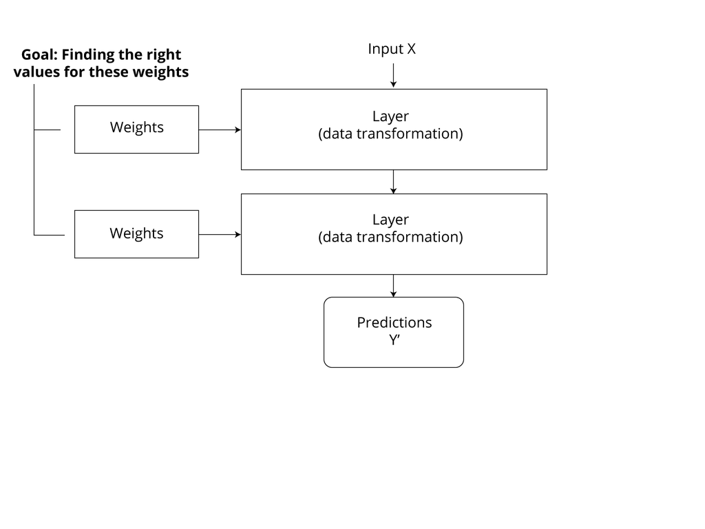

## Deep learning in three figures

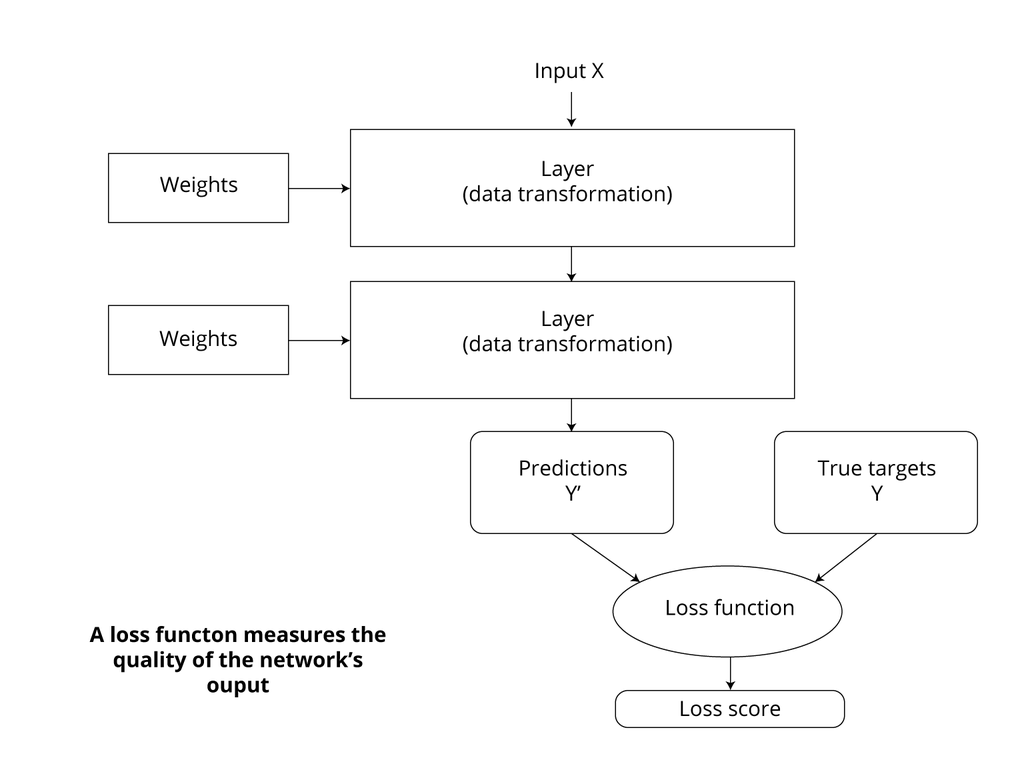

## Deep learning in three figures

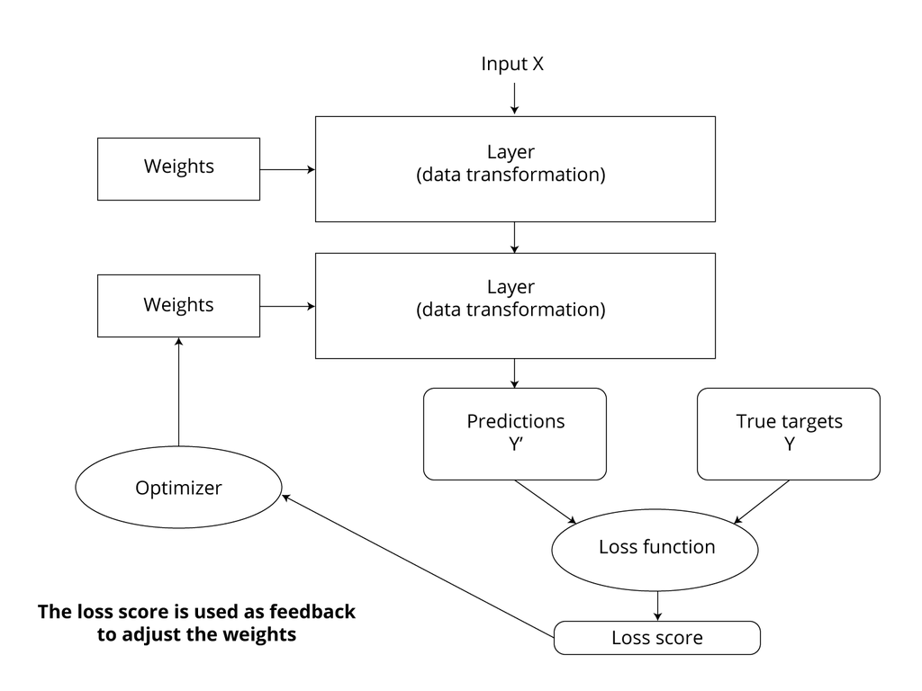

## Keras

### High level building blocks

- Build model in R (or Python) with Keras
- Execute model using TensorFlow (or other tensor library)

## The importance of MHC I antigen processing

## Which MHC I allotype does each peptide bind to?

- Build a peptide classification model for five MHC I allotypes
- Use the immune epitope database (IEDB) for peptide training data
- Predict the classification for peptides from experimental data
- Compare to *best in class* predictor NetMHC

## Raw IEDB peptide data

```r
iedb_peps %>% sample_n(5)
```

```
## # A tibble: 5 x 27
##   `Epitope ID` `Object Type` Description `Epitope Modifi~ `Epitope Modifi~
##          <int> <chr>         <chr>       <chr>            <chr>
## 1       468253 Linear pepti~ LPTVPGSSI   <NA>             <NA>
## 2       509910 Linear pepti~ LPQEIKANV   <NA>             <NA>
## 3       463972 Linear pepti~ DAFNTTFISTI <NA>             <NA>
## 4       450283 Linear pepti~ YPPAPFMHI   <NA>             <NA>
## 5       464203 Linear pepti~ EAAEVILRV   <NA>             <NA>
## # ... with 22 more variables: `Starting Position` <int>, `Ending
## #   Position` <int>, `Non-peptidic epitope Accession` <chr>, `Epitope
## #   Synonyms` <chr>, `Antigen Name` <chr>, `Parent Protein` <chr>, `Parent
## #   Protein Accession` <chr>, `Organism Name` <chr>, `Parent
## #   Organism` <chr>, `Parent Organism ID` <int>, `Epitope Comments` <chr>,
## #   `Epitope Relationship` <chr>, `Object Type_1` <chr>,
## #   Description_1 <chr>, `Starting Position_1` <int>, `Ending
## #   Position_1` <int>, `Non-peptidic object Accession` <chr>,
## #   Synonyms <chr>, `Antigen Name_1` <chr>, `Parent Protein_1` <chr>,
## #   `Organism Name_1` <chr>, `Parent Organism_1` <chr>
```

## Tidy IEDB Peptide data

```r
pep_dat %>% sample_n(10)
```

```
## # A tibble: 10 x 4
##    peptide   label_chr label_num data_type
##    <chr>     <chr>         <int> <chr>
##  1 RAIDFSPYL C03               3 train
##  2 LPPPPMQYI B51               2 train
##  3 FSIKMFLTV C15               4 train
##  4 DPYATAFLV B51               2 train
##  5 FALGAGTAL C03               3 test
##  6 SIIDEFLHI C15               4 train
##  7 NADSATRLL C03               3 train
##  8 FASTILHLV C15               4 train
##  9 ILRNPGFAL C03               3 train
## 10 GEVAPSMFL B40               1 train
```

## Encoding the peptides

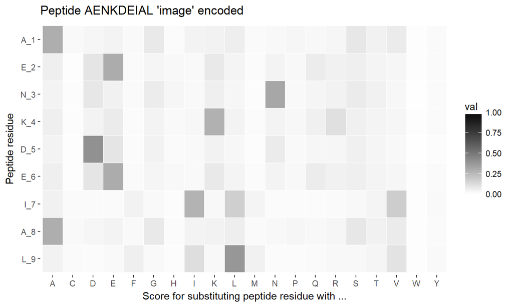

## Define a sequential model

```r
# Input shape: 9 peptides x 20 amino acids = 180
# Output shape : 5 MHC I allotypes
# relu activation : function for performing non-linear transformations.
# expanding hypothesis space.
# Dropout layer : helps deal with overfitting. Drops features from output layer.

# Initialize sequential model
model <- keras_model_sequential()

# Build architecture
model %>%
  layer_dense(units  = 180, activation = 'relu', input_shape = 180) %>%
  layer_dropout(rate = 0.4) %>%
  layer_dense(units  = 90, activation  = 'relu') %>%
  layer_dropout(rate = 0.3) %>%
  layer_dense(units  = 5, activation   = 'softmax') # Return probability scores
                                                    # for each class
# Total params: 49,325
```

## Compile and train the model

```r
# Compile model
model %>% compile(
  loss      = 'categorical_crossentropy', # Feedback loss function, distance.
  optimizer = optimizer_rmsprop(),        # Gradient descent rules
  metrics   = c('accuracy'))              # How often we match the target

# Train the model
history <- model %>% fit(
  x_train, y_train,
  epochs           = 10,   # 10 iterations over all training data
  batch_size       = 80,   # 80 peptides per batch
  validation_split = 0.2)  # Use 20% of training data for validation targets
```

## Training

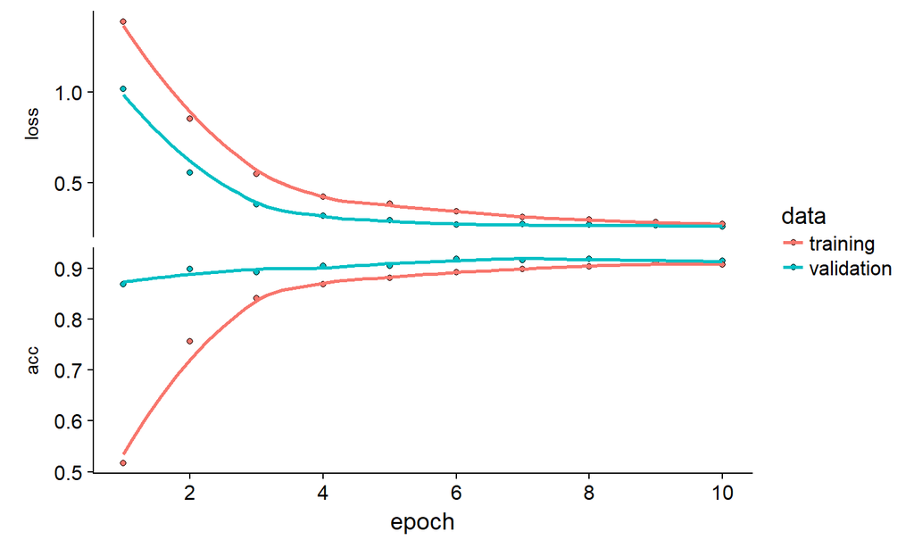

## Evaluation on IEDB test set

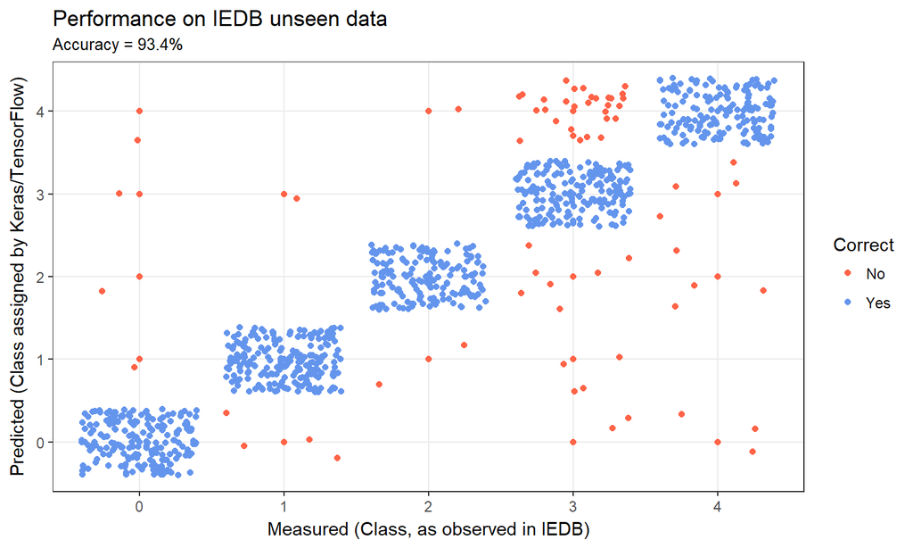

## Prediction for new data

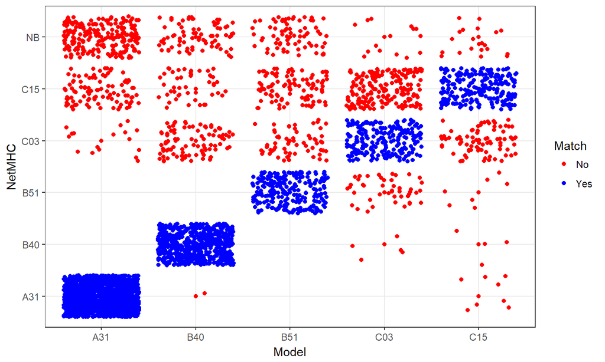

| Model | NetMHC | N_peptides | Percent |
| --- | --- | --- | --- |
| A31 | A31 | 1470 | 81.7 |
| B40 | B40 | 617 | 74.2 |
| C15 | C15 | 225 | 64.7 |
| B51 | B51 | 233 | 50 |
| C03 | C03 | 222 | 46.6 |
| C03 | C15 | 188 | 39.5 |
| C15 | C03 | 83 | 23.9 |
| B51 | C15 | 96 | 20.6 |
| B51 | NB | 74 | 15.9 |
| B51 | C03 | 63 | 13.5 |

[output cut: 14 more lines]

## Reason for underperformance?

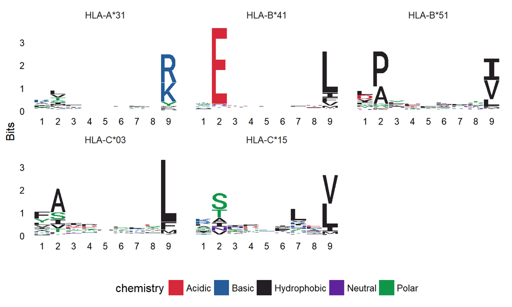

## Peptides NetMHC missed

```r
shared_peps %>%
  filter(label_chr.y == "NB") %>%
  inner_join(pep_dat, by = "peptide") %>%
  sample_n(6) %>%
  select(peptide, model_class = label_chr.x, iedb_class = label_chr)
```

```
## # A tibble: 6 x 3
##   peptide   model_class iedb_class
##   <chr>     <chr>       <chr>
## 1 NAFLEKKTV B51         B51
## 2 LILTPTREL C03         C03
## 3 VNGRLLLTL C15         C15
## 4 DAALDFKNV B51         B51
## 5 FDAKRLIGR A31         A31
## 6 QLGQFLQHR A31         A31
```

## Further investigations

- Get more training data
- Add another feature i.e. binding affinity
- Compare with unsupervised learning e.g. clustering

## Summary

- You can build a deep learning model in 20 or so lines of R code.
- Obtaining and preparing training data requires significantly more work and more code.

slides: http://ab604.github.io/mhc_tensorflow_presentation.html

email: ab604@soton.ac.uk

twitter: @alistair604